# Capstone Project: Multivariate Linear Regression Model

Author

Megan Marsh

```r
CapstoneProjectUpdated2 <- read.csv("Capstone/CapstoneProjectUpdated2 - CapstoneProjectUpdated (1).csv")

#omit missing values (CapstoneProjectUpdated2Clean has additional variables than CapstoneUpdatedClean)
CapstoneProjectUpdated2Clean <- na.omit(CapstoneProjectUpdated2)

#multivariate linear model
linear_regression_model_three <- lm(GraduationRate ~ CovidIndicator+ PercentWhite+ PercentWomen + Staff:CovidIndicator + AvgInStateTuition + RetentionRate + TotalEnrollment+ AvgPellGrant + AvgStudentLoans, data = CapstoneProjectUpdated2Clean)

summary(linear_regression_model_three)
```

```
Call:
lm(formula = GraduationRate ~ CovidIndicator + PercentWhite +
    PercentWomen + Staff:CovidIndicator + AvgInStateTuition +
    RetentionRate + TotalEnrollment + AvgPellGrant + AvgStudentLoans,
    data = CapstoneProjectUpdated2Clean)

Residuals:
    Min      1Q  Median      3Q     Max
-56.591  -7.349  -1.005   6.063  79.530

Coefficients:
                       Estimate Std. Error t value Pr(>|t|)
(Intercept)          -2.242e+01  4.122e+00  -5.438 6.95e-08 ***
CovidIndicator       -2.085e+00  9.901e-01  -2.106  0.03550 *
PercentWhite          6.705e-02  2.624e-02   2.555  0.01078 *
PercentWomen          8.390e-02  3.198e-02   2.624  0.00885 **
AvgInStateTuition     6.205e-04  4.257e-05  14.575  < 2e-16 ***
RetentionRate         3.863e-01  3.459e-02  11.170  < 2e-16 ***
TotalEnrollment       2.944e-04  7.096e-05   4.148 3.67e-05 ***
AvgPellGrant          1.535e-03  4.529e-04   3.390  0.00073 ***
AvgStudentLoans       2.177e-03  2.627e-04   8.287 4.22e-16 ***
CovidIndicator:Staff  5.976e-04  2.402e-04   2.488  0.01303 *
---
Signif. codes:  0 '***' 0.001 '**' 0.01 '*' 0.05 '.' 0.1 ' ' 1

Residual standard error: 13.3 on 894 degrees of freedom
Multiple R-squared:  0.6081,    Adjusted R-squared:  0.6042
F-statistic: 154.2 on 9 and 894 DF,  p-value: < 2.2e-16
```

```r
print(linear_regression_model_three)
```

```
Call:
lm(formula = GraduationRate ~ CovidIndicator + PercentWhite +
    PercentWomen + Staff:CovidIndicator + AvgInStateTuition +
    RetentionRate + TotalEnrollment + AvgPellGrant + AvgStudentLoans,
    data = CapstoneProjectUpdated2Clean)

Coefficients:
         (Intercept)        CovidIndicator          PercentWhite
          -2.242e+01            -2.085e+00             6.705e-02
        PercentWomen     AvgInStateTuition         RetentionRate
           8.390e-02             6.205e-04             3.863e-01
     TotalEnrollment          AvgPellGrant       AvgStudentLoans
           2.944e-04             1.536e-03             2.177e-03
CovidIndicator:Staff
           5.976e-04
```

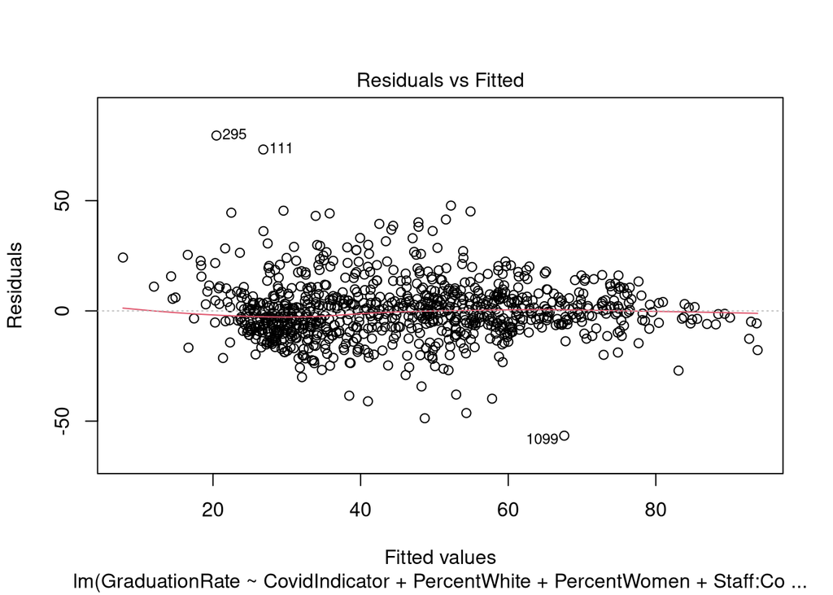

```r
#linearity tests: residuals vs. fitted plot and rainbow test

#residuals vs. fitted: the residuals should be randomly scattered around a horizontal line at zero
#patterns or curves indicate non-linearity
plot(linear_regression_model_three, 1)
```

```r
#rainbow test for non-linearity
#null hypothesis: the relationship between the dependent variable and each independent variables is linear

library(lmtest)
raintest(linear_regression_model_three)
```

```
    Rainbow test

data:  linear_regression_model_three
Rain = 0.9484, df1 = 452, df2 = 442, p-value = 0.7123
```

It appears the residuals are mostly randomly scattered around a horizontal line at zero. There are no distinct patterns of curves present, confirming linearity. For an added layer of assurance, the rainbow test will be used to assess linearity. When using this rainbow test, the p-value of 0.7123 (not below the chosen significance level of 0.05) suggests that there is not enough evidence to reject the null hypothesis. Thus, there is not enough evidence to reject the assumption of linearity of this multivariate linear regression model.

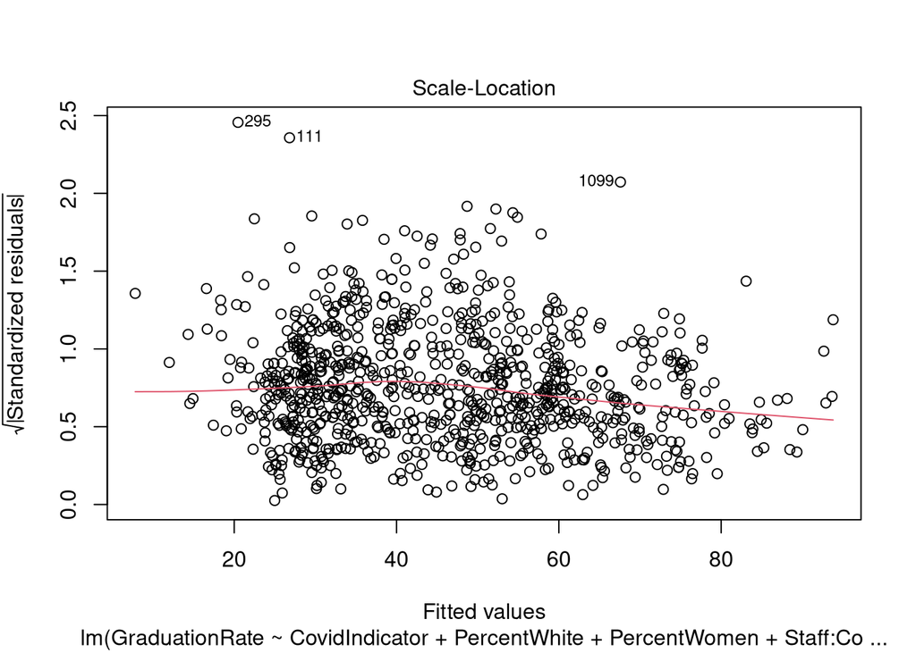

```r
#test for homoscedasticity using the scale-location plot
#the points should be randomly scattered around a horizontal line and no funnel shape patterns should be present
plot(linear_regression_model_three, 3)
```

```r
#non-constant variance test for homoscedasticity
#null hypothesis: the variance of the error terms (residuals) in regression model is constant (homoscedasticity)
library(car)
ncvTest(linear_regression_model_three)
```

```
Non-constant Variance Score Test
Variance formula: ~ fitted.values
Chisquare = 23.13446, Df = 1, p = 1.5106e-06
```

```r
#breusch-pagan test for homoscedasticity
#null hypothesis: the variance of the error terms (residuals) in regression model is constant (homoscedasticity)
bptest(linear_regression_model_three)
```

```
    studentized Breusch-Pagan test

data:  linear_regression_model_three
BP = 49.888, df = 9, p-value = 1.131e-07
```

The scale-location plot seems a bit inconclusive and therefore, additional testing is needed to determine homoscedasticity. The two homoscedasticity test used were the Non-Constant Variance Test and Breusch-Pagan Test. Both test have very small p-values (below the chosen significance level of 0.05), providing sufficient evidence to reject the null hypothesis of homoscedasticity. Thus, there heterscedasticity is present in the model.

```r
#durbin-waston test for independence of errors (no autocorrelation)

#a durbin-watson statistic around 2 indicates no autocorrelation (values significantly below 2 suggest positive autocorrelation and values significantly above 2 suggest negative autocorrelation)
library(car)
durbinWatsonTest(linear_regression_model_three)
```

```
 lag Autocorrelation D-W Statistic p-value
   1      0.07097861      1.849568   0.022
 Alternative hypothesis: rho != 0
```

```r
#breusch-godfrey test for independence of errors (no autocorrelation)
library(lmtest)
bgtest(linear_regression_model_three)
```

```
    Breusch-Godfrey test for serial correlation of order up to 1

data:  linear_regression_model_three
LM test = 4.8266, df = 1, p-value = 0.02802
```

Those so far, the multivariate linear regression model has fulfilled the assumption of linearity but not homoscedasticity and autocorrelation. Therefore, various robust standard errors techniques are used to adjust the variance-covariance matrix of the coefficient estimators in a manner that accounts for the potential autocorrelation and heteroscedasticity in the residuals.

```r
library(sandwich)
library(lmtest)

#using HC
robust_se_hc1 <- coeftest(linear_regression_model_three, vcov. = vcovHC(linear_regression_model_three, type = "HC1"))
print("Results with HC1 Robust Standard Errors:")
```

```
[1] "Results with HC1 Robust Standard Errors:"
```

```r
print(robust_se_hc1)
```

```
t test of coefficients:

                        Estimate  Std. Error t value  Pr(>|t|)
(Intercept)          -2.2418e+01  4.7043e+00 -4.7655 2.198e-06 ***
CovidIndicator       -2.0850e+00  1.0106e+00 -2.0631  0.039387 *
PercentWhite          6.7047e-02  3.2676e-02  2.0519  0.040470 *
PercentWomen          8.3897e-02  4.4511e-02  1.8848  0.059774 .
AvgInStateTuition     6.2051e-04  4.6047e-05 13.4757 < 2.2e-16 ***
RetentionRate         3.8632e-01  5.3967e-02  7.1584 1.702e-12 ***
TotalEnrollment       2.9436e-04  6.7130e-05  4.3849 1.298e-05 ***
AvgPellGrant          1.5355e-03  4.6794e-04  3.2814  0.001073 **
AvgStudentLoans       2.1768e-03  2.5753e-04  8.4526 < 2.2e-16 ***
CovidIndicator:Staff  5.9763e-04  1.3271e-04  4.5033 7.577e-06 ***
---
Signif. codes:  0 '***' 0.001 '**' 0.01 '*' 0.05 '.' 0.1 ' ' 1
```

```r
#using HC3 (better for smaller sample sizes)
robust_se_hc3 <- coeftest(linear_regression_model_three, vcov. = vcovHC(linear_regression_model_three, type = "HC3"))
print("Results with HC3 Robust Standard Errors:")
```

```
[1] "Results with HC3 Robust Standard Errors:"
```

```r
print(robust_se_hc3)
```

```
t test of coefficients:

                        Estimate  Std. Error t value  Pr(>|t|)
(Intercept)          -2.2418e+01  4.7721e+00 -4.6977 3.044e-06 ***
CovidIndicator       -2.0850e+00  1.0187e+00 -2.0467  0.040982 *
PercentWhite          6.7047e-02  3.3064e-02  2.0278  0.042877 *
PercentWomen          8.3897e-02  4.4957e-02  1.8662  0.062347 .
AvgInStateTuition     6.2051e-04  4.6542e-05 13.3322 < 2.2e-16 ***
RetentionRate         3.8632e-01  5.4622e-02  7.0726 3.068e-12 ***
TotalEnrollment       2.9436e-04  6.9401e-05  4.2414 2.452e-05 ***
AvgPellGrant          1.5355e-03  4.7984e-04  3.2000  0.001423 **
AvgStudentLoans       2.1768e-03  2.6128e-04  8.3311 2.994e-16 ***
CovidIndicator:Staff  5.9763e-04  1.4583e-04  4.0983 4.541e-05 ***
---
Signif. codes:  0 '***' 0.001 '**' 0.01 '*' 0.05 '.' 0.1 ' ' 1
```

```r
#using newey-west standard errors (for BOTH autocorrelation and heteroskedasticity)
#requires a time-series component and data must be ordered by year
CapstoneProjectUpdated2Clean <- CapstoneProjectUpdated2Clean[order(CapstoneProjectUpdated2Clean$Year), ]

robust_se_newey_west <- coeftest(linear_regression_model_three, vcov. = NeweyWest(linear_regression_model_three))
print("Results with Newey-West Robust Standard Errors:")
```

```
[1] "Results with Newey-West Robust Standard Errors:"
```

```r
print(robust_se_newey_west)
```

```
t test of coefficients:

                        Estimate  Std. Error t value  Pr(>|t|)
(Intercept)          -2.2418e+01  4.8851e+00 -4.5891 5.087e-06 ***
CovidIndicator       -2.0850e+00  1.0059e+00 -2.0729  0.038471 *
PercentWhite          6.7047e-02  3.3756e-02  1.9862  0.047314 *
PercentWomen          8.3897e-02  4.3330e-02  1.9362  0.053156 .
AvgInStateTuition     6.2051e-04  4.3541e-05 14.2513 < 2.2e-16 ***
RetentionRate         3.8632e-01  5.0985e-02  7.5771 8.820e-14 ***
TotalEnrollment       2.9436e-04  7.4274e-05  3.9632 7.986e-05 ***
AvgPellGrant          1.5355e-03  4.8377e-04  3.1740  0.001555 **
AvgStudentLoans       2.1768e-03  2.3951e-04  9.0883 < 2.2e-16 ***
CovidIndicator:Staff  5.9763e-04  1.3687e-04  4.3665 1.410e-05 ***
---
Signif. codes:  0 '***' 0.001 '**' 0.01 '*' 0.05 '.' 0.1 ' ' 1
```

For this study, I used the results with newey-west robust standard errors as it adjusted the model p-values appropriately with the presence of autocorrelation and heteroskedasticity. Although, it should be noted that all robust standard erorr techniques produced very similar results.

According to the multivariate linear regression, beginning in 2020, the graduation rate is estimated to be 2.085 percentage points lower, holding all other factors constant.

```r
#due to having panel data, clustering by Unit ID is an option
#this was not used in my project

library(clubSandwich)

clustered_se <- coeftest(linear_regression_model_three, vcov. = vcovCR(linear_regression_model_three, cluster = CapstoneProjectUpdated2Clean$UnitID, type = "CR2"))
print("Results with Clustered Robust Standard Errors:")
```

```
[1] "Results with Clustered Robust Standard Errors:"
```

```r
print(clustered_se)
```

```
t test of coefficients:

                        Estimate  Std. Error t value  Pr(>|t|)
(Intercept)          -2.2418e+01  7.7823e+00 -2.8807  0.004063 **
CovidIndicator       -2.0850e+00  9.6991e-01 -2.1497  0.031849 *
PercentWhite          6.7047e-02  4.9365e-02  1.3582  0.174746
PercentWomen          8.3897e-02  8.9329e-02  0.9392  0.347886
AvgInStateTuition     6.2051e-04  8.5311e-05  7.2735 7.653e-13 ***
RetentionRate         3.8632e-01  8.7917e-02  4.3941 1.245e-05 ***
TotalEnrollment       2.9436e-04  1.4958e-04  1.9679  0.049386 *
AvgPellGrant          1.5355e-03  5.5529e-04  2.7652  0.005805 **
AvgStudentLoans       2.1768e-03  4.3887e-04  4.9599 8.440e-07 ***
CovidIndicator:Staff  5.9763e-04  6.2921e-04  0.9498  0.342462
---
Signif. codes:  0 '***' 0.001 '**' 0.01 '*' 0.05 '.' 0.1 ' ' 1
```

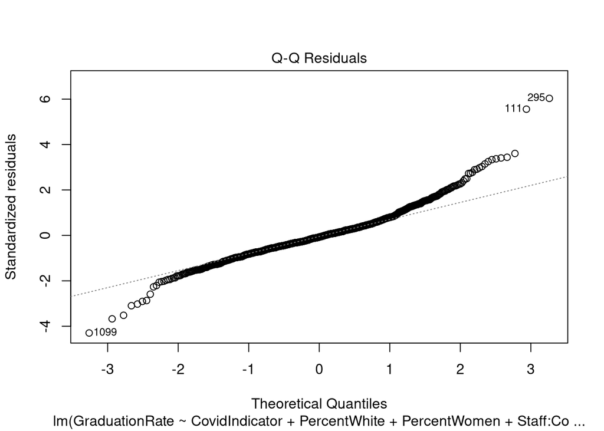

```r
#Q-Q Plot to test for the normality of residuals
#if normally distributed, the points will fall approximately along a straight line
plot(linear_regression_model_three, 2)
```

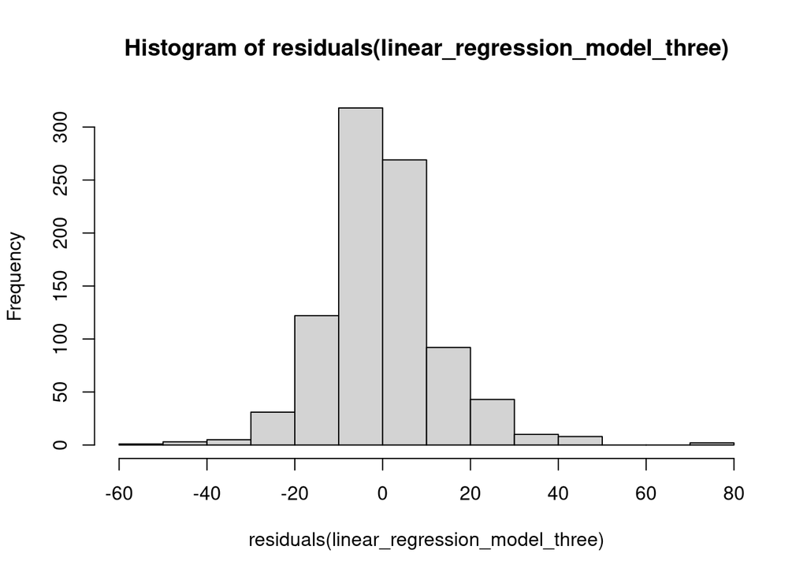

```r
#visual representation of the distribution of the residuals
hist(residuals(linear_regression_model_three))
```

```r
#shapiro-wilk test for normal distribution of residuals
#null hypothesis: data is normally distributed
shapiro.test(residuals(linear_regression_model_three))
```

```
    Shapiro-Wilk normality test

data:  residuals(linear_regression_model_three)
W = 0.95262, p-value < 2.2e-16
```

While the distribution appears somewhat bell-shaped in the histogram, the bars are uneven, indicating deviations from the smooth, symmetrical curve of a perfect normal distribution. The Shapiro-Wilk test yielded a very small p-value (significantly below the chosen significance level of 0.05), providing sufficient evidence to reject the null hypothesis of normality of residuals. However, by the Central Limit Theorem, since we have a reasonable large sample size, the rejections of normality of residuals is not a major concern for the validity of inferences about the regression coefficients.

```r
#calculation for no multicollinearity

#VIF values greater than 5 or 10 are generally considered to indicate high multicollinearity
#ideally VIF value should be close to one
library(car)
vif(linear_regression_model_three, type="predictor")
```

```
                      GVIF Df GVIF^(1/(2*Df)) Interacts With
CovidIndicator    1.846999  2        1.165780          Staff
PercentWhite      1.180674  1        1.086588           --
PercentWomen      1.149785  1        1.072280           --
Staff             1.846999  2        1.165780          Staff
AvgInStateTuition 1.884441  1        1.372749           --
RetentionRate     1.665698  1        1.290619           --
TotalEnrollment   1.820281  1        1.349178           --
AvgPellGrant      1.310222  1        1.144649           --
AvgStudentLoans   1.527362  1        1.235865           --
                                                                                                                       Other Predictors
CovidIndicator             PercentWhite, PercentWomen, AvgInStateTuition, RetentionRate, TotalEnrollment, AvgPellGrant, AvgStudentLoans
PercentWhite      CovidIndicator, PercentWomen, Staff, AvgInStateTuition, RetentionRate, TotalEnrollment, AvgPellGrant, AvgStudentLoans
PercentWomen      CovidIndicator, PercentWhite, Staff, AvgInStateTuition, RetentionRate, TotalEnrollment, AvgPellGrant, AvgStudentLoans
Staff                      PercentWhite, PercentWomen, AvgInStateTuition, RetentionRate, TotalEnrollment, AvgPellGrant, AvgStudentLoans
AvgInStateTuition      CovidIndicator, PercentWhite, PercentWomen, Staff, RetentionRate, TotalEnrollment, AvgPellGrant, AvgStudentLoans
RetentionRate      CovidIndicator, PercentWhite, PercentWomen, Staff, AvgInStateTuition, TotalEnrollment, AvgPellGrant, AvgStudentLoans
TotalEnrollment      CovidIndicator, PercentWhite, PercentWomen, Staff, AvgInStateTuition, RetentionRate, AvgPellGrant, AvgStudentLoans
AvgPellGrant      CovidIndicator, PercentWhite, PercentWomen, Staff, AvgInStateTuition, RetentionRate, TotalEnrollment, AvgStudentLoans
AvgStudentLoans      CovidIndicator, PercentWhite, PercentWomen, Staff, AvgInStateTuition, RetentionRate, TotalEnrollment, AvgPellGrant
```

All value inflation factors are close to one, solidifying no multicollinearity.

In conclusion, a graph was constructed to visualize the multivariate linear regressions model fit (remember the multiple R-squared value was 0.6081).

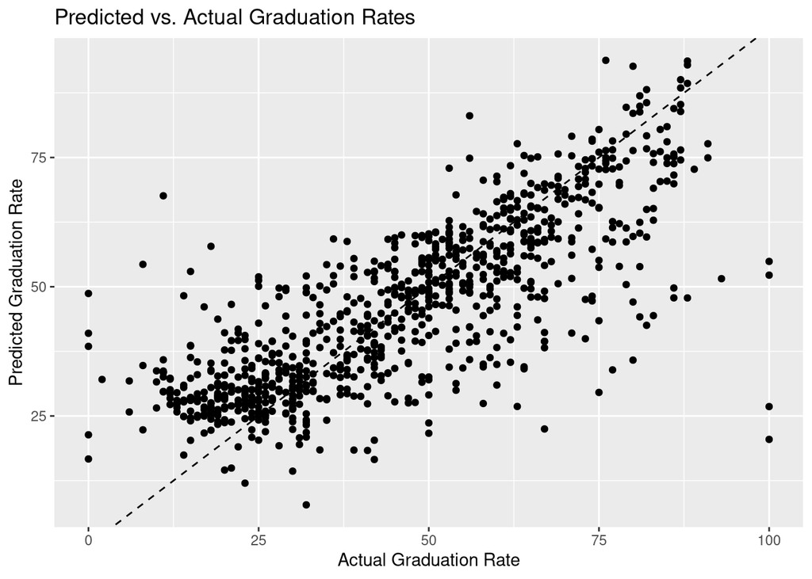

```r
library(ggplot2)

predicted_values <- predict(linear_regression_model_three, newdata = CapstoneProjectUpdated2Clean)

ggplot(data.frame(CapstoneProjectUpdated2Clean$GraduationRate, predicted_values),
       aes(x = CapstoneProjectUpdated2Clean$GraduationRate, y = predicted_values)) +
  geom_point() +
  geom_abline(intercept = 0, slope = 1, linetype = "dashed") +
  labs(title = "Predicted vs. Actual Graduation Rates",
       x = "Actual Graduation Rate",
       y = "Predicted Graduation Rate")
```

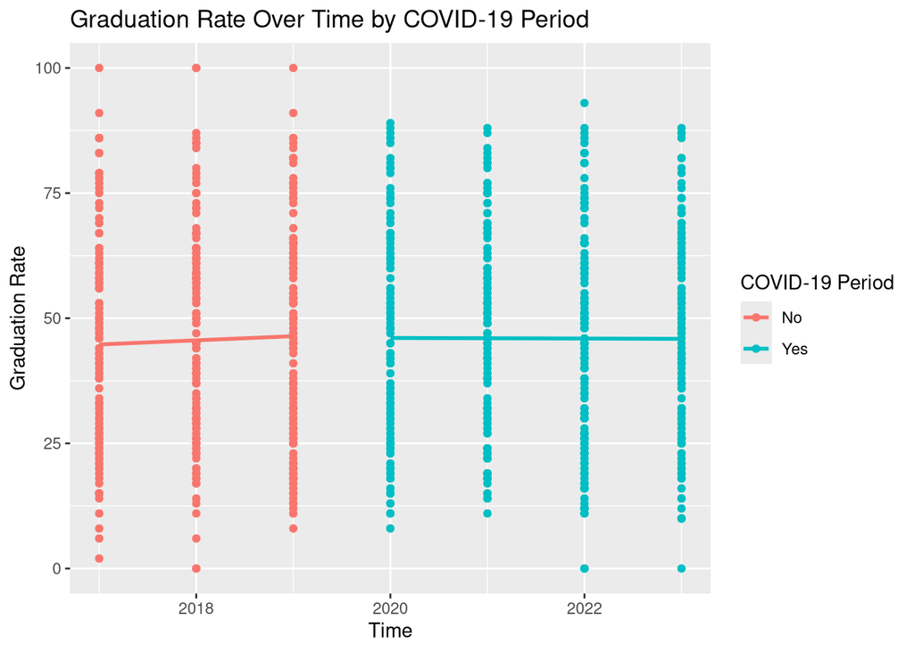

```r
#scatter plot with regression lines highlighting pre and post pandemic periods
library(ggplot2)

ggplot(CapstoneProjectUpdated2Clean, aes(x = Year, y = GraduationRate, color = factor(CovidIndicator))) +
  geom_point() +
  geom_smooth(method = "lm", se = FALSE) +
  labs(title = "Graduation Rate Over Time by COVID-19 Period",
       x = "Time",
       y = "Graduation Rate",
       color = "COVID-19 Period") +
  scale_color_discrete(labels = c("No", "Yes"))
```